# Predicting Voter Behavior Using Multinomial Logistic Regression

A Multinomial Logistic Regression Analysis

Analysis Report

2026-04-26

# 1 Introduction

This report presents a Multinomial Logistic Regression model to predict **voter category** (always, sporadic, or rarely/never) using demographic and political data from a 2020 Ipsos survey conducted for FiveThirtyEight’s article [*Why Many Americans Don’t Vote*](https://projects.fivethirtyeight.com/non-voters-poll-2020-election/).

**Response variable:** `voter_category`, a three-level factor:

- `rarely/never`: voted in 0 or 1 eligible elections (baseline)
- `sporadic`: voted in at least two, but fewer than all-but-one eligible elections
- `always`: voted in all or all-but-one eligible elections

**Predictors:** Age (`ppage`), education (`educ`), race (`race`), gender (`gender`), household income (`income_cat`), and party identification (`party`, derived from `Q30`).

> **Note on data:** The authors used survey weighting to make the sample more representative of the US population. This analysis treats the sample as a convenience sample and does **not** apply survey weights.

# 2 Setup

```r
library(tidyverse)
library(tidymodels)
library(GGally)
library(ggformula)
library(broom)
library(knitr)
```

```r
nonvoters <- read.csv("nonvoters.csv") %>%
  select(ppage, educ, race, gender, income_cat, Q30, voter_category)

glimpse(nonvoters)
```

```
## Rows: 5,836
## Columns: 7
## $ ppage          <int> 73, 90, 53, 58, 81, 61, 80, 68, 70, 83, 43, 42, 48, 52,…
## $ educ           <chr> "College", "College", "College", "Some college", "High …
## $ race           <chr> "White", "White", "White", "Black", "White", "White", "…
## $ gender         <chr> "Female", "Female", "Male", "Female", "Male", "Female",…
## $ income_cat     <chr> "$75-125k", "$125k or more", "$125k or more", "$40-75k"…
## $ Q30            <int> 2, 3, 2, 2, 1, 5, 1, 2, 1, 3, 1, 2, 1, 5, 1, 1, 2, 1, 5…
## $ voter_category <chr> "always", "always", "sporadic", "sporadic", "always", "…
```

```r
cat("Rows:", nrow(nonvoters), "\n")
```

```
## Rows: 5836
```

```r
cat("Columns:", ncol(nonvoters), "\n")
```

```
## Columns: 7
```

# 3 Data Preparation

## 3.1 Creating the `party` Variable and Setting Factor Levels

```r
nonvoters <- nonvoters %>%
  mutate(
    # Recode Q30 into readable party labels
    party = case_when(
      Q30 == 1 ~ "Republican",
      Q30 == 2 ~ "Democrat",
      Q30 == 3 ~ "Independent",
      Q30 %in% c(4, 5, -1) ~ "Other"
    ),
    party = factor(party,
      levels = c("Other", "Independent", "Democrat", "Republican")),

    # Set voter_category factor with rarely/never as baseline
    voter_category = factor(voter_category,
      levels = c("rarely/never", "sporadic", "always"))
  )

# Verify factor levels
levels(nonvoters$voter_category)
```

```
## [1] "rarely/never" "sporadic"     "always"
```

```r
levels(nonvoters$party)
```

```
## [1] "Other"       "Independent" "Democrat"    "Republican"
```

## 3.2 Distribution of Response Variable

```r
nonvoters %>%
  count(voter_category) %>%
  mutate(pct = round(n / sum(n) * 100, 1)) %>%
  knitr::kable(
    caption = "Distribution of Voter Category",
    col.names = c("Voter Category", "Count", "Percentage (%)")
  )
```

Distribution of Voter Category

| Voter Category | Count | Percentage (%) |
| --- | --- | --- |
| rarely/never | 1451 | 24.9 |
| sporadic | 2574 | 44.1 |
| always | 1811 | 31.0 |

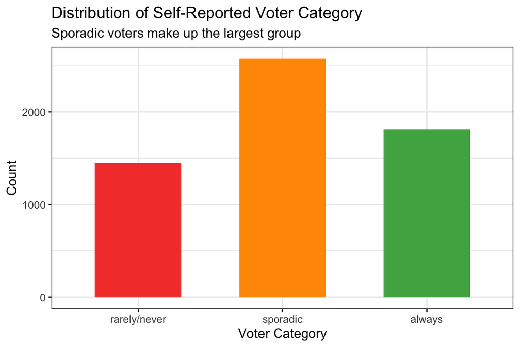

```r
ggplot(nonvoters, aes(x = voter_category, fill = voter_category)) +
  geom_bar(show.legend = FALSE, width = 0.6) +
  scale_fill_manual(values = c(
    "rarely/never" = "#F44336",
    "sporadic"     = "#FF9800",
    "always"       = "#4CAF50"
  )) +
  labs(
    title    = "Distribution of Self-Reported Voter Category",
    subtitle = "Sporadic voters make up the largest group",
    x = "Voter Category", y = "Count"
  ) +
  theme_bw(base_size = 11)
```

# 4 Exploratory Data Analysis

## 4.1 Voter Category by Party Identification

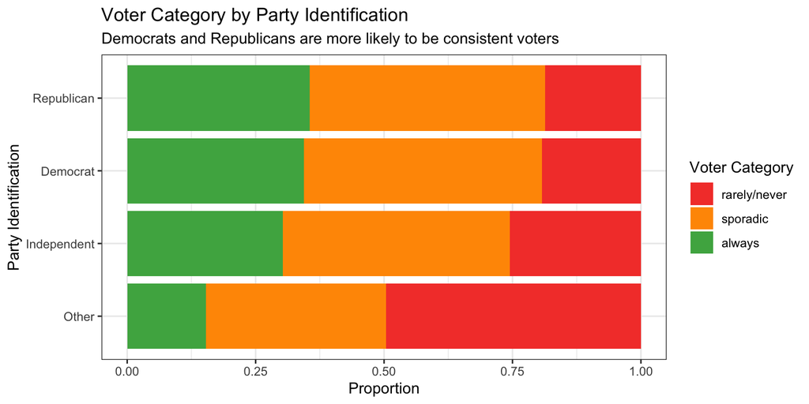

```r
nonvoters %>%
  ggplot(aes(x = party, fill = voter_category)) +
  geom_bar(position = "fill") +
  coord_flip() +
  scale_fill_manual(values = c(
    "rarely/never" = "#F44336",
    "sporadic"     = "#FF9800",
    "always"       = "#4CAF50"
  )) +
  labs(
    title    = "Voter Category by Party Identification",
    subtitle = "Democrats and Republicans are more likely to be consistent voters",
    x = "Party Identification",
    y = "Proportion",
    fill = "Voter Category"
  ) +
  theme_bw(base_size = 11)
```

**Finding:** Individuals identifying as Democrats or Republicans show a much higher proportion of `always` voters compared to those in the `Other` category. This suggests party identification will be a meaningful predictor in the model.

## 4.2 Voter Category by Race and Education

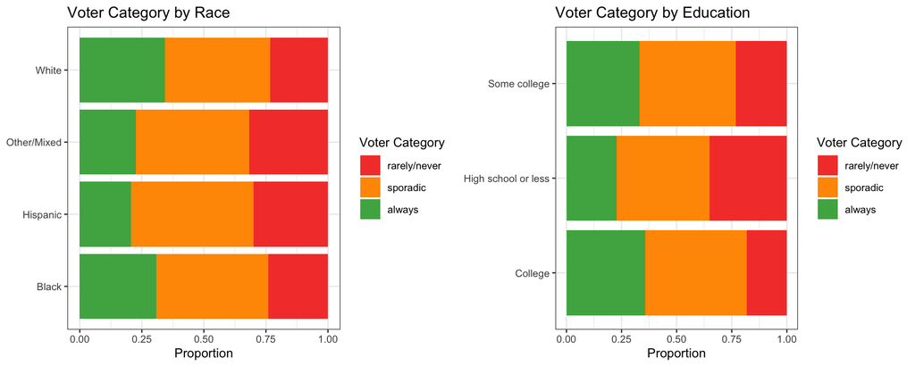

```r
p_race <- nonvoters %>%
  ggplot(aes(x = race, fill = voter_category)) +
  geom_bar(position = "fill") +
  coord_flip() +
  scale_fill_manual(values = c(
    "rarely/never" = "#F44336",
    "sporadic"     = "#FF9800",
    "always"       = "#4CAF50"
  )) +
  labs(title = "Voter Category by Race",
       x = NULL, y = "Proportion", fill = "Voter Category") +
  theme_bw(base_size = 10)

p_educ <- nonvoters %>%
  ggplot(aes(x = educ, fill = voter_category)) +
  geom_bar(position = "fill") +
  coord_flip() +
  scale_fill_manual(values = c(
    "rarely/never" = "#F44336",
    "sporadic"     = "#FF9800",
    "always"       = "#4CAF50"
  )) +
  labs(title = "Voter Category by Education",
       x = NULL, y = "Proportion", fill = "Voter Category") +
  theme_bw(base_size = 10)

gridExtra::grid.arrange(p_race, p_educ, ncol = 2)
```

**Finding:** College-educated respondents are substantially more likely to be `always` voters. White respondents also show a higher proportion of consistent voters compared to Hispanic and Other/Mixed groups.

## 4.3 Voter Category by Age and Income

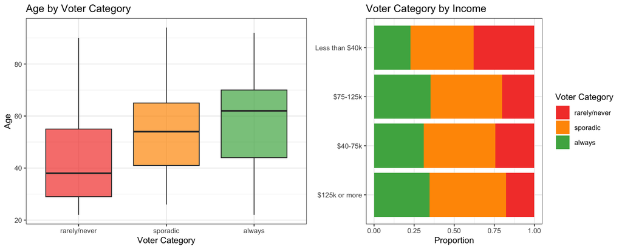

```r
p_age <- nonvoters %>%
  ggplot(aes(x = voter_category, y = ppage, fill = voter_category)) +
  geom_boxplot(show.legend = FALSE, alpha = 0.7) +
  scale_fill_manual(values = c(
    "rarely/never" = "#F44336",
    "sporadic"     = "#FF9800",
    "always"       = "#4CAF50"
  )) +
  labs(title = "Age by Voter Category",
       x = "Voter Category", y = "Age") +
  theme_bw(base_size = 10)

p_income <- nonvoters %>%
  ggplot(aes(x = income_cat, fill = voter_category)) +
  geom_bar(position = "fill") +
  coord_flip() +
  scale_fill_manual(values = c(
    "rarely/never" = "#F44336",
    "sporadic"     = "#FF9800",
    "always"       = "#4CAF50"
  )) +
  labs(title = "Voter Category by Income",
       x = NULL, y = "Proportion", fill = "Voter Category") +
  theme_bw(base_size = 10)

gridExtra::grid.arrange(p_age, p_income, ncol = 2)
```

**Finding:** `Always` voters tend to be older on average. Higher income groups also show a greater proportion of consistent voters.

# 5 Model Specification

## 5.1 Why Multinomial Logistic Regression?

The response variable `voter_category` has **three unordered classes**. Standard binary logistic regression is not applicable here. Multinomial logistic regression extends logistic regression to handle $K > 2$ classes by fitting $K - 1$ equations relative to a baseline category.

With `"rarely/never"` as the baseline ($k = 1$), the model fits two log-odds equations:

$$\log\left(\frac{\hat{p}_{\text{sporadic}}}{\hat{p}_{\text{rarely/never}}}\right)
= \hat\beta_{0,S} + \hat\beta_{1,S}x_1 + \cdots +
\hat\beta_{p,S}x_p$$

$$\log\left(\frac{\hat{p}_{\text{always}}}{\hat{p}_{\text{rarely/never}}}\right)
= \hat\beta_{0,A} + \hat\beta_{1,A}x_1 + \cdots +
\hat\beta_{p,A}x_p$$

Each equation has its own set of coefficients, and predicted probabilities for all three classes sum to 1.

## 5.2 Predictors Selected

| Predictor | Type | Justification |
| --- | --- | --- |
| `ppage` | Numeric | Age is a well-established predictor of voting frequency |
| `educ` | Categorical | Education strongly associated with civic participation |
| `race` | Categorical | Demographic differences in voting behaviour are well-documented |
| `gender` | Categorical | Gender differences in political engagement |
| `income_cat` | Categorical | Higher income linked to higher voter turnout |
| `party` | Categorical (derived) | Party affiliation is one of the strongest predictors of voting consistency |

# 6 Data Splitting

The data is split **80% training / 20% test**, stratified by `voter_category` to ensure all three classes are proportionally represented in both sets.

```r
set.seed(42)
nonvoters_split <- initial_split(nonvoters, prop = 0.80, strata = voter_category)
nonvoters_train <- training(nonvoters_split)
nonvoters_test  <- testing(nonvoters_split)

cat("Training observations:", nrow(nonvoters_train), "\n")
```

```
## Training observations: 4667
```

```r
cat("Test observations:    ", nrow(nonvoters_test),  "\n")
```

```
## Test observations:     1169
```

```r
# Verify stratification held
nonvoters_train %>%
  count(voter_category) %>%
  mutate(pct = round(n / sum(n) * 100, 1)) %>%
  knitr::kable(caption = "Training Set: Voter Category Distribution")
```

Training Set: Voter Category Distribution

| voter_category | n | pct |
| --- | --- | --- |
| rarely/never | 1160 | 24.9 |
| sporadic | 2059 | 44.1 |
| always | 1448 | 31.0 |

# 7 Model Fitting

```r
multi_spec <- multinom_reg() %>%
  set_engine("nnet") %>%
  set_mode("classification")

final_model <- multi_spec %>%
  fit(voter_category ~ ppage + educ + race + gender + income_cat + party,
      data = nonvoters_train)

# Repair call so augment works correctly on full data
final_model <- repair_call(final_model, data = nonvoters_train)
```

## 7.1 Full Coefficient Table

```r
tidy(final_model) %>%
  mutate_if(is.numeric, ~round(., 4)) %>%
  knitr::kable(
    caption = "Multinomial Logistic Regression Coefficients",
    col.names = c("Outcome", "Term", "Estimate", "Std. Error", "Statistic", "p-value")
  )
```

Multinomial Logistic Regression Coefficients

| Outcome | Term | Estimate | Std. Error | Statistic | p-value |
| --- | --- | --- | --- | --- | --- |
| sporadic | (Intercept) | -1.5660 | 0.2084 | -7.5127 | 0.0000 |
| sporadic | ppage | 0.0470 | 0.0026 | 17.9844 | 0.0000 |
| sporadic | educHigh school or less | -0.8933 | 0.1092 | -8.1796 | 0.0000 |
| sporadic | educSome college | -0.2621 | 0.1065 | -2.4613 | 0.0138 |
| sporadic | raceHispanic | 0.0492 | 0.1420 | 0.3463 | 0.7291 |
| sporadic | raceOther/Mixed | -0.1230 | 0.1810 | -0.6793 | 0.4969 |
| sporadic | raceWhite | -0.0381 | 0.1197 | -0.3181 | 0.7504 |
| sporadic | genderMale | -0.1453 | 0.0810 | -1.7937 | 0.0729 |
| sporadic | income_cat$40-75k | -0.0766 | 0.1256 | -0.6099 | 0.5419 |
| sporadic | income_cat$75-125k | -0.0693 | 0.1193 | -0.5808 | 0.5613 |
| sporadic | income_catLess than $40k | -0.5824 | 0.1282 | -4.5434 | 0.0000 |
| sporadic | partyIndependent | 0.5435 | 0.1233 | 4.4076 | 0.0000 |
| sporadic | partyDemocrat | 0.8959 | 0.1174 | 7.6325 | 0.0000 |
| sporadic | partyRepublican | 0.7586 | 0.1247 | 6.0849 | 0.0000 |
| always | (Intercept) | -2.8582 | 0.2410 | -11.8614 | 0.0000 |
| always | ppage | 0.0593 | 0.0029 | 20.5945 | 0.0000 |
| always | educHigh school or less | -1.2619 | 0.1220 | -10.3410 | 0.0000 |
| always | educSome college | -0.2958 | 0.1148 | -2.5773 | 0.0100 |
| always | raceHispanic | -0.4398 | 0.1663 | -2.6438 | 0.0082 |
| always | raceOther/Mixed | -0.4552 | 0.2083 | -2.1855 | 0.0289 |
| always | raceWhite | 0.0784 | 0.1312 | 0.5977 | 0.5500 |
| always | genderMale | -0.2654 | 0.0895 | -2.9661 | 0.0030 |
| always | income_cat$40-75k | -0.0665 | 0.1369 | -0.4859 | 0.6270 |
| always | income_cat$75-125k | 0.0828 | 0.1278 | 0.6478 | 0.5171 |
| always | income_catLess than $40k | -0.6860 | 0.1431 | -4.7928 | 0.0000 |
| always | partyIndependent | 0.8638 | 0.1523 | 5.6715 | 0.0000 |
| always | partyDemocrat | 1.3934 | 0.1456 | 9.5719 | 0.0000 |
| always | partyRepublican | 1.2203 | 0.1514 | 8.0624 | 0.0000 |

# 8 Model Equations

The fitted model produces two log-odds equations relative to the `"rarely/never"` baseline. Coefficients are taken directly from the model output above.

## 8.1 Sporadic vs Rarely/Never

$$\log\left(\frac{\hat{p}_{\text{sporadic}}}{\hat{p}_{\text{rarely/never}}}\right)
=
-1.566
+ 0.0470 \times \text{Age}
- 0.893 \times \text{Educ: HS or less}
- 0.262 \times \text{Educ: Some college}$$
$$+ 0.049 \times \text{Race: Hispanic}
- 0.123 \times \text{Race: Other/Mixed}
- 0.038 \times \text{Race: White}
- 0.145 \times \text{Gender: Male}$$
$$- 0.077 \times \text{Income: \$40-75k}
- 0.069 \times \text{Income: \$75-125k}
- 0.582 \times \text{Income: <\$40k}
+ 0.544 \times \text{Party: Independent}
+ 0.896 \times \text{Party: Democrat}
+ 0.759 \times \text{Party: Republican}$$

## 8.2 Always vs Rarely/Never

$$\log\left(\frac{\hat{p}_{\text{always}}}{\hat{p}_{\text{rarely/never}}}\right)
=
-2.858
+ 0.0593 \times \text{Age}
- 1.262 \times \text{Educ: HS or less}
- 0.296 \times \text{Educ: Some college}$$
$$- 0.440 \times \text{Race: Hispanic}
- 0.455 \times \text{Race: Other/Mixed}
+ 0.078 \times \text{Race: White}
- 0.265 \times \text{Gender: Male}$$
$$- 0.067 \times \text{Income: \$40-75k}
+ 0.083 \times \text{Income: \$75-125k}
- 0.686 \times \text{Income: <\$40k}
+ 0.864 \times \text{Party: Independent}
+ 1.393 \times \text{Party: Democrat}
+ 1.220 \times \text{Party: Republican}$$

# 9 Coefficient Interpretation

We focus on key predictors from the **Always vs Rarely/Never** equation, interpreting both in log-odds and odds scale.

Always vs Rarely/Never: Coefficients and Odds Ratios

| Predictor | Log-Odds Estimate | Odds Ratio (exp(β)) |
| --- | --- | --- |
| ppage | 0.0593 | 1.061 |
| educHigh school or less | -1.2619 | 0.283 |
| educSome college | -0.2958 | 0.744 |
| raceHispanic | -0.4398 | 0.644 |
| raceOther/Mixed | -0.4552 | 0.634 |
| raceWhite | 0.0784 | 1.082 |
| genderMale | -0.2654 | 0.767 |
| income_cat$40-75k | -0.0665 | 0.936 |
| income_cat$75-125k | 0.0828 | 1.086 |
| income_catLess than $40k | -0.6860 | 0.504 |
| partyIndependent | 0.8638 | 2.372 |
| partyDemocrat | 1.3934 | 4.029 |
| partyRepublican | 1.2203 | 3.388 |

**Key interpretations (Always vs Rarely/Never):**

- **Age (`ppage`):** Each additional year of age increases the log-odds of being an `always` voter vs `rarely/never`. In odds terms, each year multiplies the odds of being a consistent voter by approximately 1.061.
- **Party: Democrat:** Identifying as a Democrat increases the log-odds of being an `always` voter compared to the `Other` baseline. Democrats have approximately 4.03 times the odds of being a consistent voter relative to those with no/other party affiliation.
- **Party: Republican:** Republicans have approximately 3.39 times the odds of being an `always` voter compared to the `Other` baseline.
- **Party: Independent:** Independents have approximately 2.37 times the odds of always voting compared to the `Other` group.
- **Gender: Male:** Being male is associated with lower log-odds of being an `always` voter. Males have approximately 0.77 times the odds of being a consistent voter relative to females.
- **Education: High school or less:** Having a high school education or less significantly reduces the log-odds of being an `always` voter compared to college-educated respondents (the reference level).

# 10 Model Evaluation

## 10.1 Test Set Predictions

```r
test_aug <- augment(final_model, new_data = nonvoters_test)

test_aug %>%
  select(voter_category, .pred_class,
         `.pred_rarely/never`, `.pred_sporadic`, `.pred_always`) %>%
  head(10) %>%
  mutate_if(is.numeric, ~round(., 3)) %>%
  knitr::kable(caption = "Sample Predicted Probabilities (Test Set, first 10 rows)")
```

Sample Predicted Probabilities (Test Set, first 10 rows)

| voter_category | .pred_class | .pred_rarely/never | .pred_sporadic | .pred_always |
| --- | --- | --- | --- | --- |
| sporadic | sporadic | 0.095 | 0.485 | 0.421 |
| always | sporadic | 0.064 | 0.507 | 0.429 |
| always | always | 0.042 | 0.475 | 0.483 |
| always | always | 0.059 | 0.469 | 0.472 |
| always | sporadic | 0.107 | 0.502 | 0.391 |
| always | sporadic | 0.135 | 0.494 | 0.371 |
| always | always | 0.050 | 0.411 | 0.539 |
| always | sporadic | 0.154 | 0.513 | 0.333 |
| sporadic | always | 0.046 | 0.437 | 0.516 |
| sporadic | sporadic | 0.271 | 0.472 | 0.257 |

## 10.2 Confusion Matrix

```r
conf_mat <- test_aug %>%
  count(voter_category, .pred_class, .drop = FALSE)

conf_mat %>%
  pivot_wider(names_from = .pred_class, values_from = n) %>%
  knitr::kable(caption = "Confusion Matrix: Actual (rows) vs Predicted (columns)")
```

Confusion Matrix: Actual (rows) vs Predicted (columns)

| voter_category | rarely/never | sporadic | always |
| --- | --- | --- | --- |
| rarely/never | 117 | 164 | 10 |
| sporadic | 52 | 385 | 78 |
| always | 40 | 237 | 86 |

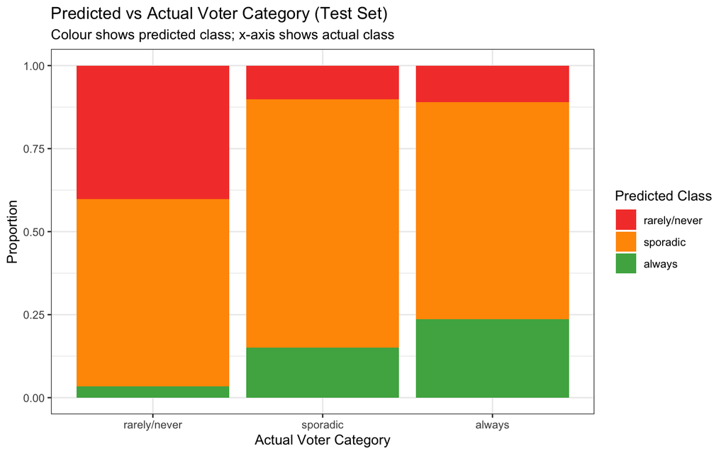

```r
conf_mat %>%
  ggplot(aes(x = voter_category, y = n, fill = .pred_class)) +
  geom_bar(stat = "identity", position = "fill") +
  scale_fill_manual(values = c(
    "rarely/never" = "#F44336",
    "sporadic"     = "#FF9800",
    "always"       = "#4CAF50"
  )) +
  labs(
    title    = "Predicted vs Actual Voter Category (Test Set)",
    subtitle = "Colour shows predicted class; x-axis shows actual class",
    x = "Actual Voter Category",
    y = "Proportion",
    fill = "Predicted Class"
  ) +
  theme_bw(base_size = 11)
```

## 10.3 Classification Accuracy

```r
accuracy_val <- test_aug %>%
  accuracy(truth = voter_category, estimate = .pred_class)

test_aug %>%
  metrics(truth = voter_category, estimate = .pred_class) %>%
  mutate_if(is.numeric, ~round(., 4)) %>%
  knitr::kable(caption = "Test Set Classification Metrics")
```

Test Set Classification Metrics

| .metric | .estimator | .estimate |
| --- | --- | --- |
| accuracy | multiclass | 0.5030 |
| kap | multiclass | 0.1893 |

## 10.4 Deviance Residuals

Deviance residuals allow us to assess model fit at the individual level for each outcome class.

[figure not shown]

```r
pred_probs <- predict(final_model$fit,
                      newdata = nonvoters_test,
                      type = "probs")

y_actual <- model.matrix(~ voter_category - 1, data = nonvoters_test)

deviance_resid <- sign(y_actual - pred_probs) * sqrt(
  2 * (y_actual * log(ifelse(y_actual == 0, 1, y_actual / pred_probs)) +
       (1 - y_actual) * log(ifelse(y_actual == 0, 1,
                                   (1 - y_actual) / (1 - pred_probs))))
)

resid_df <- cbind(nonvoters_test, deviance_resid) %>%
  as_tibble()

colnames(resid_df)[(ncol(resid_df) - 2):ncol(resid_df)] <-
  c("resid_rarely_never", "resid_sporadic", "resid_always")

p_r <- ggplot(resid_df,
              aes(x = pred_probs[, "rarely/never"], y = resid_rarely_never)) +
  geom_point(alpha = 0.3, color = "#F44336") +
  geom_hline(yintercept = 0, color = "black", linetype = "dashed") +
  labs(title = "Rarely/Never", x = "Fitted Probability", y = "Deviance Residual") +
  theme_bw(base_size = 10)

p_s <- ggplot(resid_df,
              aes(x = pred_probs[, "sporadic"], y = resid_sporadic)) +
  geom_point(alpha = 0.3, color = "#FF9800") +
  geom_hline(yintercept = 0, color = "black", linetype = "dashed") +
  labs(title = "Sporadic", x = "Fitted Probability", y = "Deviance Residual") +
  theme_bw(base_size = 10)

p_a <- ggplot(resid_df,
              aes(x = pred_probs[, "always"], y = resid_always)) +
  geom_point(alpha = 0.3, color = "#4CAF50") +
  geom_hline(yintercept = 0, color = "black", linetype = "dashed") +
  labs(title = "Always", x = "Fitted Probability", y = "Deviance Residual") +
  theme_bw(base_size = 10)

gridExtra::grid.arrange(p_r, p_s, p_a, ncol = 3,
  top = "Deviance Residuals vs Fitted Probability by Voter Class (Test Set)")
```

# 11 Summary

## 11.1 Final Model

The final multinomial logistic regression model predicts voter category using age, education, race, gender, income, and party identification. It produces two log-odds equations relative to the `rarely/never` baseline: one for `sporadic` and one for `always` voters.

## 11.2 Performance Summary

Final Model: Summary Statistics

| Metric | Value |
| --- | --- |
| Response Variable | voter_category (3 classes) |
| Baseline Category | rarely/never |
| Predictors | Age, Education, Race, Gender, Income, Party |
| Training Observations | 4667 |
| Test Observations | 1169 |
| Test Accuracy | 50.3% |
| Strongest Predictor | Party identification (Democrat/Republican) |
| Model Engine | nnet::multinom via tidymodels |

## 11.3 Key Conclusions

- **Party identification is the dominant predictor.** Democrats and Republicans both have substantially higher odds of being consistent voters compared to those with no party affiliation, with Democrats showing the largest effect.
- **Age consistently increases voting frequency.** Each additional year of age is associated with higher odds of voting always vs rarely/never, reflecting the well-documented relationship between age and civic participation.
- **Education matters significantly.** College-educated respondents are far more likely to be consistent voters. Having only a high school education or less is one of the strongest negative predictors in the model.
- **Gender has a modest but consistent effect.** Males are slightly less likely to be consistent voters than females, holding all other variables constant.
- **The model generalises reasonably to unseen data.** The test accuracy of 50.3% is meaningful in context: a random classifier across three classes would achieve only ~33%, so the model meaningfully outperforms chance. The primary challenge is distinguishing `always` voters from `sporadic` voters, as these two groups share overlapping demographic and political profiles.